# R Notebook

### - *Consumo de bebidas alcohólicas durante el confinamiento:*

### **Análisis univariado:**

##### En esta variable se analizo el impacto durante el confinamiento en la frecuencia del consumo de bebidas alcohólicas en los estudiantes de UTEC, donde se obtuvo los siguientes resultados:

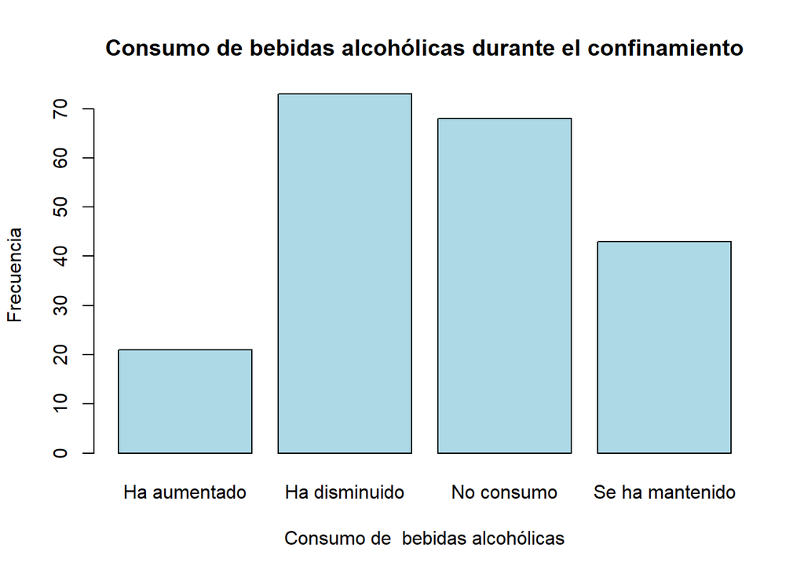

```r
counts <- table(BD$`Consumo de bebidas alcohólicas durante el confinamiento`)
barplot(counts, main="Consumo de bebidas alcohólicas durante el confinamiento", xlab = "Consumo de  bebidas alcohólicas", ylab = "Frecuencia",
        col=c("light blue"))
```

##### De este grafico podemos afirmar que los alumnos de la Universidad de Ingenieria y Tecnologia han disminuido el consumo de bebidas alcohólicas durante el confinamiento. Seguidamente de un gran grupo de estudiantes que directamente no consumen este producto.

```r
cat('Número de observaciones:', nrow(BD),'\n')
```

```
## Número de observaciones: 205
```

```r
cat('Número de casos completos de la variable consumo de bebidas alcohólicas durante el confinamiento:', sum(complete.cases(BD$`Consumo de bebidas alcohólicas durante el confinamiento`)),'\n')
```

```
## Número de casos completos de la variable consumo de bebidas alcohólicas durante el confinamiento: 205
```

##### El número de observaciones y el numero de casos completos para la variable de consumo de bebidas alcohólicas durante el confinamiento es 205, por lo que la muestra selectiva para el análisis de esta variable es 205 observaciones.

```r
cat('Moda de la variable consumo de bebidas alcohólicas durante el confinamiento:', "Ha disminuido" ,'\n')
```

```
## Moda de la variable consumo de bebidas alcohólicas durante el confinamiento: Ha disminuido
```